# >> **CONCEITO COMEX**

Relatório por: Ricardo Aguirre Leal (ricardo.leal@furg.br)

Versão 1.0 – 21 março, 2021

# 1 ANÁLISE DA ATRIBUIÇÃO MANUAL - *Tópicos do conceito*

Atribuição do conceito a um tópico realizado pelos pesquisadores do trabalho. Quantidade de tópicos e tópicos criados de acordo com a precepção dos pesquisadores; antes dos procedimentos e resultados do *text mining*

## 1.1 Construção dos dados

### 1.1.1 Exclusão trabalhos não classificados quanto à publicação ou tópico ou sem palavras-chave

A quantidade de trabalhos sem a classificação do tópico é 5

Sem a classificação de um ou outro é 13

A quantidade de trabalhos restante, após exclusão dos não classificados é 511

Afff… :( Tem classificações em mais de um tópico. De forma arbitrária, mantive a da classificação que fica na coluna mais à esquerda…

*Lista dos trabalhos sem classificação de publicação ou tópico:*

| ano | titulo | keywords | falta_publ | falta_topi |
| --- | --- | --- | --- | --- |
| 2016 | BARREIRAS INTELECTUAIS: UM IMPEDIMENTO AO COMÉRCIO | comércio internacional; agreste pernambucano; mercado; dificuldades intelectuais | TRUE | FALSE |
| 2017 | A CONTRIBUIÇÃO DO ACORDO DE FACILITAÇÃO DE COMÉRCI | Acordo de Facilitação de Comércio; OMC; Economias em desenvolvimento | TRUE | FALSE |
| 2017 | Saúde Pública versus Comércio Internacional: o ace | NA | TRUE | FALSE |
| 2018 | A RELAÇÃO ENTRE INVESTIMENTO ESTRANGEIRO DIRETO E | investimento estrangeiro direto; modelo gravitacional; Brasil | TRUE | FALSE |
| 2018 | Acordos Bilaterais e Desequilíbrios no Comércio In | Regional Trade Agreements; comércio internacional; desequilíbrio comercial | TRUE | FALSE |
| 2018 | Economia digital: impactos tributários e de comérc | NA | TRUE | FALSE |
| 2018 | O Comércio Internacional de Serviços e as Política | NA | TRUE | FALSE |
| 2018 | O DESENVOLVIMENTO DO COMÉRCIO INTERNACIONAL IRLAND | Desenvolvimento; Irlanda; Porto; Dublin; Logística | TRUE | FALSE |
| 2018 | SOBRE O COMÉRCIO EXTERIOR DOS PAÍSES DA ZONA DO EU | União Europeia; Zona do Euro; Comércio Internacional; Crise de 2008 | TRUE | FALSE |
| 2019 | Comércio internacional em tempos de crise: exporta | Exportações; Serviços; Bens; Brasil; Mundo | TRUE | FALSE |

[output cut: 3 more lines]

### 1.1.2 Exclusão dos trabalhos sem as palavras-chave

A exclusão é feita depois de já retirados os trabalhos sem classificação de publicação ou tópico

A quantidade de trabalhos sem as palavras-chave (keywords) é 45

A quantidade de trabalhos restante para análise é 466

*Lista dos trabalhos sem palavras-chave, depois de já retirados os trabalhos sem publicação ou tópico:*

| ano | titulo | keywords |
| --- | --- | --- |
| 2010 | A eficiência do comércio internacional como promot | NA |
| 2010 | Barreiras Técnicas ao comécio internacional: Impac | NA |
| 2010 | Comércio exterior do nordeste (1990-2008) e dilema | NA |
| 2010 | Dependência e Monopólio no comércio internacional | NA |
| 2010 | Modelo de Mensuração de Impactos Econômicos Relaci | NA |
| 2010 | O comércio internacional como promotor de crescime | NA |
| 2010 | O Comércio Internacional de Feijões - Oportunidade | NA |
| 2010 | Perspectivas para o Brasil no Comércio Internacion | NA |
| 2010 | Relações de trabalho e comércio internacional: Índ | NA |
| 2010 | Tendências e características da inserção da UEMOA | NA |

[output cut: 35 more lines]

## 1.2 Tokenization, por palavra, das palavras-chave

Aqui, tokens são as palavras das palavras-chave (keywords). Poderíamos optar por tokens como expressões (possivelmente mais de uma palavra), e.g. as palavras entre ponto-e-vírgulas.

### 1.2.1 Exclusão das stopwords e de números constante no conjunto das palavras

Stopwords são palavras comuns na língua e que possuem pouco significado para a análise.

Nos nossos documentos e suas palavras-chave, as palavras com números e os próprios números, como resultados estatísticos, datas etc., não tem muito significado em nossa análise de significado de COMEX, por isso retiramos os tokens com números. (Mesmo estando usando as palavras-chave dos trabalhos, encontrei números neles)

Todas as palavras foram convertidas para caracteres minúsculos, a fim de conformidade.

*Lista das stopwords retiradas dentre os tokens:*

| V1 | V2 | V3 | V4 | V5 | V6 |
| --- | --- | --- | --- | --- | --- |
| de | eu | essas | estão | houver | serão |
| a | também | esses | estive | houvermos | seria |
| o | só | pelas | esteve | houverem | seríamos |
| que | pelo | este | estivemos | houverei | seriam |
| e | pela | dele | estiveram | houverá | tenho |
| do | até | tu | estava | houveremos | tem |
| da | isso | te | estávamos | houverão | temos |
| em | ela | vocês | estavam | houveria | tém |
| um | entre | vos | estivera | houveríamos | tinha |
| para | depois | lhes | estivéramos | houveriam | tínhamos |

[output cut: 24 more lines]

## 1.3 Palavras-chave mais frequentes nos documentos

É um total de 1079 palavras (tokens) distintas após os ajustes anteriores

*Lista das top 100:*

| word | n |
| --- | --- |
| comércio | 348 |
| internacional | 240 |
| exterior | 85 |
| exportações | 47 |
| desenvolvimento | 45 |
| exportação | 36 |
| brasil | 34 |
| comercial | 34 |
| direito | 31 |
| econômico | 26 |

[output cut: 90 more lines]

*Gráfico das top 15:*

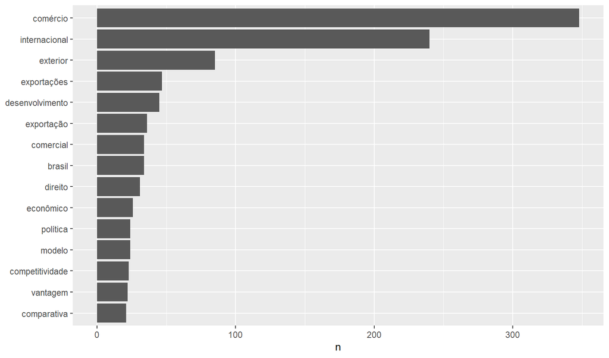

## 1.4 Stem (raiz) das Palavras-chave mais frequentes nos documentos

*Em morfologia linguística e recuperação de informação a stemização (do inglês, stemming) é o processo de reduzir palavras flexionadas (ou às vezes derivadas) ao seu tronco (stem), base ou raiz, geralmente uma forma da palavra escrita. O tronco não precisa ser idêntico à raiz morfológica da palavra; ele geralmente é suficiente que palavras relacionadas sejam mapeadas para o mesmo tronco, mesmo se este tronco não for ele próprio uma raiz válida. (Wikipedia)*. Veja https://pt.wikipedia.org/wiki/Stemiza%C3%A7%C3%A3o ou https://en.wikipedia.org/wiki/Stemming

Esse aqui é o algorítmo usitlizado no steming: Porter(1980), o mais usado https://www.emerald.com/insight/content/doi/10.1108/eb046814/full/html

Também é feita uma transformação dos caracteres com acento em sem acento, para conformidade

É um total de 902 palavras (tokens) distintas após os ajustes e a stemization

A sequir, a lista das 50 mais frequentes e o gráfico das 15 mais frequentes.

*Lista das top 50:*

| word | n |
| --- | --- |
| comerci | 350 |
| internacional | 240 |
| export | 94 |
| exterior | 85 |
| econom | 66 |
| brasil | 51 |
| desenvolv | 45 |
| compar | 39 |
| comercial | 36 |
| direit | 35 |

[output cut: 40 more lines]

A palavra tronco “export” (com ramos “exportações”, “exportação”, “exportou” etc.) passou a ser mais importante (maior frequente) que a palavra e palavra tronco “exterior”. A palavra tronco “econom” também despontou dentre as top 5.

Obs: O token “brasileir” (com frequencia de 16) apareceu como diferente do “brasil” (com 35), pois o algoritmo não considerou o segundo como tronco (stem)do primeiro. Por isso, fiz a transformação manualmente, já aplicada e apresentada na lista acima

*Gráfico das top 15:*

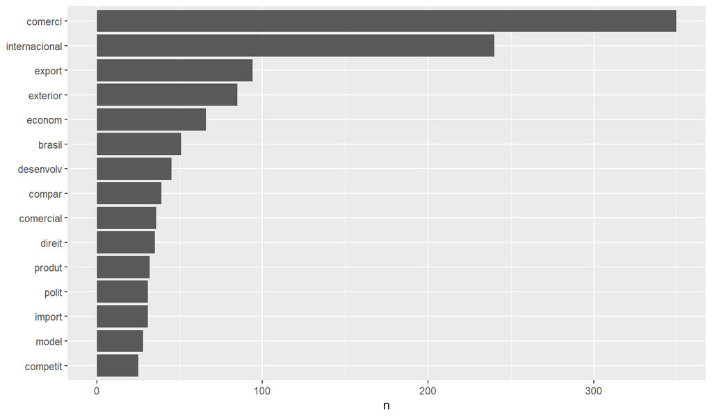

*Nuvem de palavras stem, exceto as duas primeiras (que destoam bastante):*

[interactive chart not shown]

## 1.5 Análise dos tópicos atribuídos e sua evolução

### 1.5.1 Frequência dos tópicos

*Quantidade por tópico:*

| topico | n |
| --- | --- |
| institucional | 188 |
| econ_intern | 151 |
| trocas | 77 |
| operacional | 47 |
| outros | 3 |

*Gráfico da quantidade por tópico:*

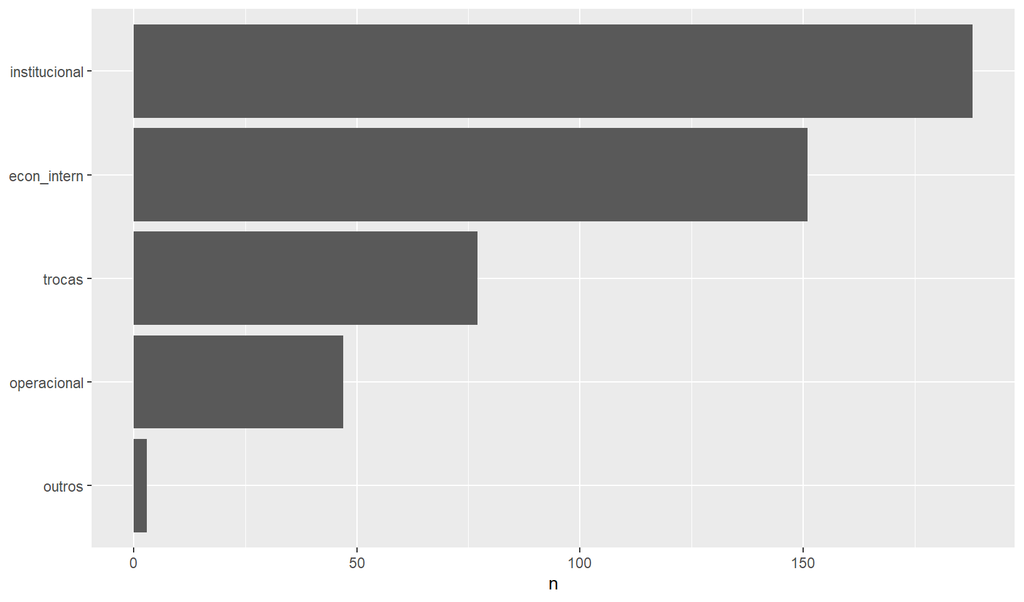

### 1.5.2 Evolução da quantidade de trabalhos e da frequência dos tópicos

*Quantidade de trabalhos por ano:*

| ano | soma_anual |
| --- | --- |
| 2010 | 29 |
| 2011 | 35 |
| 2012 | 29 |
| 2013 | 49 |
| 2014 | 39 |
| 2015 | 49 |
| 2016 | 52 |
| 2017 | 59 |
| 2018 | 50 |
| 2019 | 59 |

[output cut: 1 more lines]

*Quantidade da evolução anual da amostra de trabalhos:*

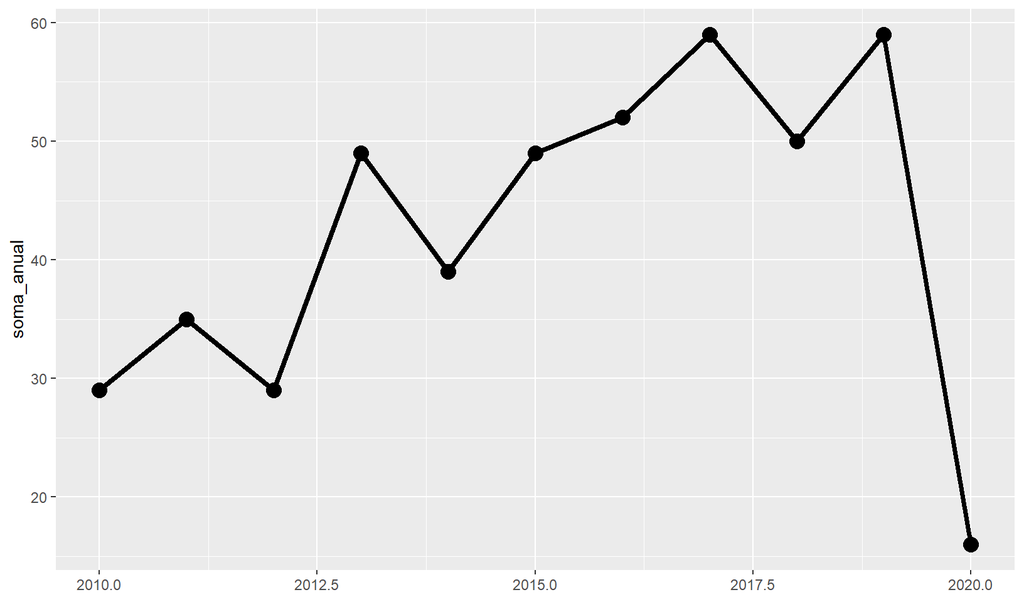

*Gráfico da evolução das frequencias absolutas anuais dos tópicos:*

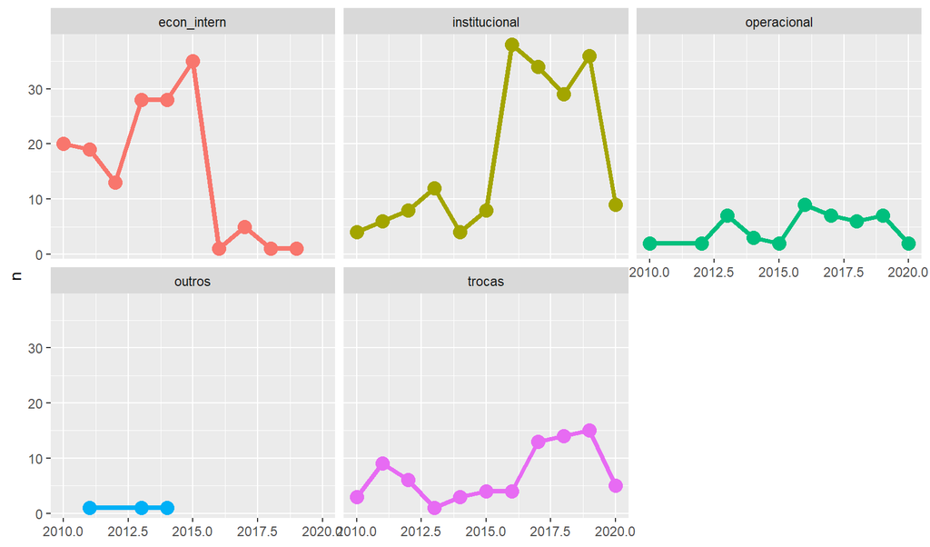

*Gráfico da evolução das frequencias relativas (%) anuais dos tópicos:*

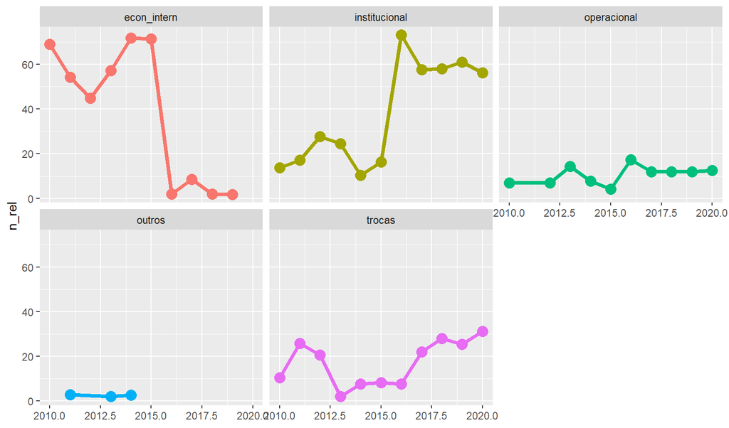

## 1.6 Análise dos tipos de publicação atribuídos e sua evolução

### 1.6.1 Frequência dos tipos de publicação

| publicacao | n |
| --- | --- |
| revista | 250 |
| tcc | 90 |
| dissertacao | 59 |
| congresso | 48 |
| tese | 19 |

*Gráfico da quantidade por tipos de publicação:*

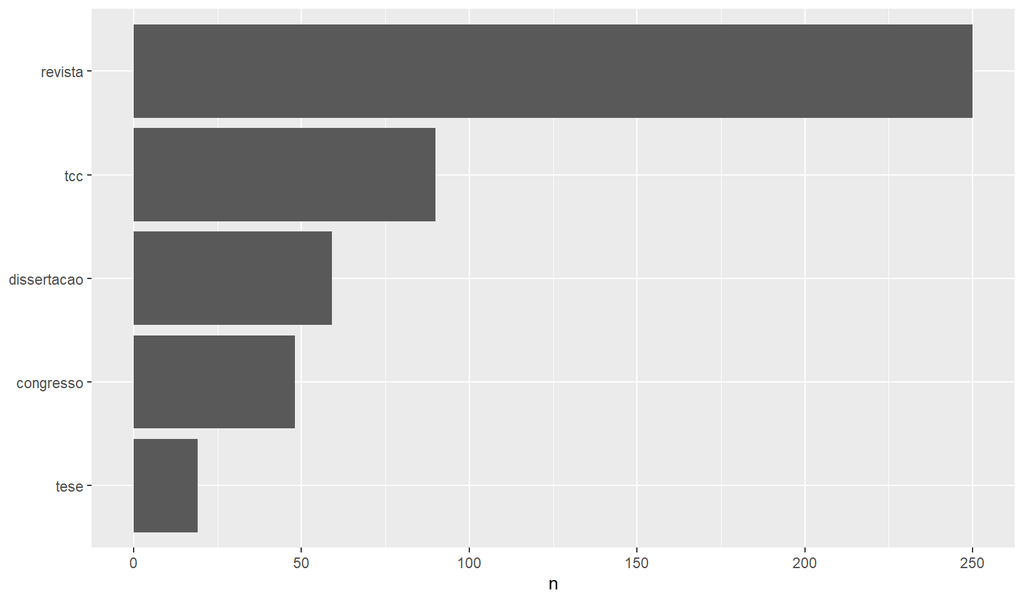

### 1.6.2 Evolução da frequência dos tipos de publicação

*Gráfico da evolução das frequencias absolutas anuais dos tipos de publicação:*

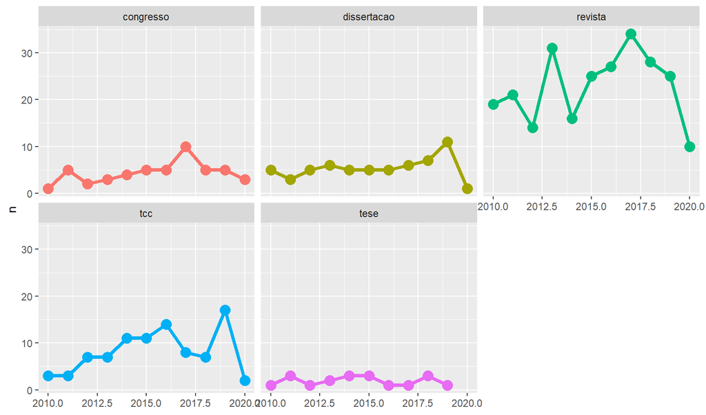

*Gráfico da evolução das frequencias relativas (%) anuais dos tipos de publicação:*

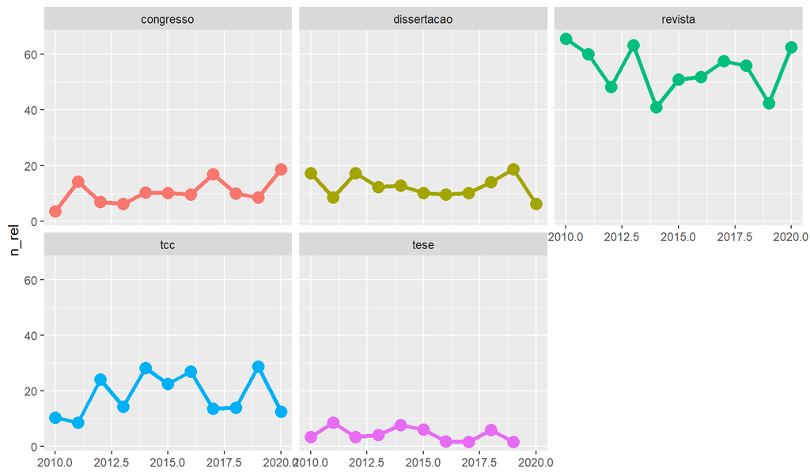

## 1.7 Análise da relação entre as frequencias dos tópicos e dos tipos de publicação

*Lista das frequencias dos pares, classificada por tipo de publicação:*

| publicacao | topico | n |
| --- | --- | --- |
| 1_revista | 1_institucional | 92 |
| 1_revista | 2_econ_intern | 84 |
| 1_revista | 3_trocas | 45 |
| 1_revista | 4_operacional | 29 |
| 2_tcc | 1_institucional | 39 |
| 2_tcc | 2_econ_intern | 32 |
| 2_tcc | 3_trocas | 13 |
| 2_tcc | 4_operacional | 5 |
| 2_tcc | 5_outros | 1 |
| 3_dissertacao | 1_institucional | 22 |

[output cut: 11 more lines]

*Lista das frequencias dos pares, classificada por tópico:*

| publicacao | topico | n |
| --- | --- | --- |
| 1_revista | 1_institucional | 92 |
| 2_tcc | 1_institucional | 39 |
| 4_congresso | 1_institucional | 25 |
| 3_dissertacao | 1_institucional | 22 |
| 5_tese | 1_institucional | 10 |
| 1_revista | 2_econ_intern | 84 |
| 2_tcc | 2_econ_intern | 32 |
| 3_dissertacao | 2_econ_intern | 14 |
| 4_congresso | 2_econ_intern | 14 |
| 5_tese | 2_econ_intern | 7 |

[output cut: 11 more lines]

*Gráfico da rede de conexões entre tópicos e tipos de publicação:*

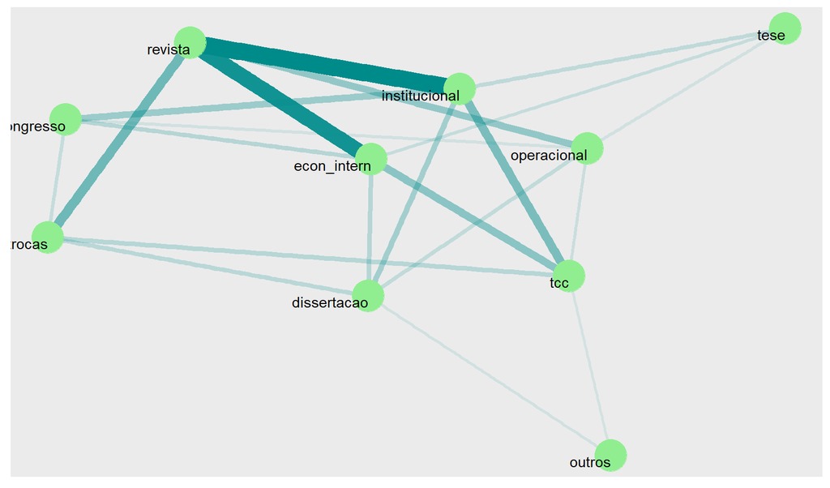

*Gráfico matricial das relações entre os tópicos e os tipos de publicação:*

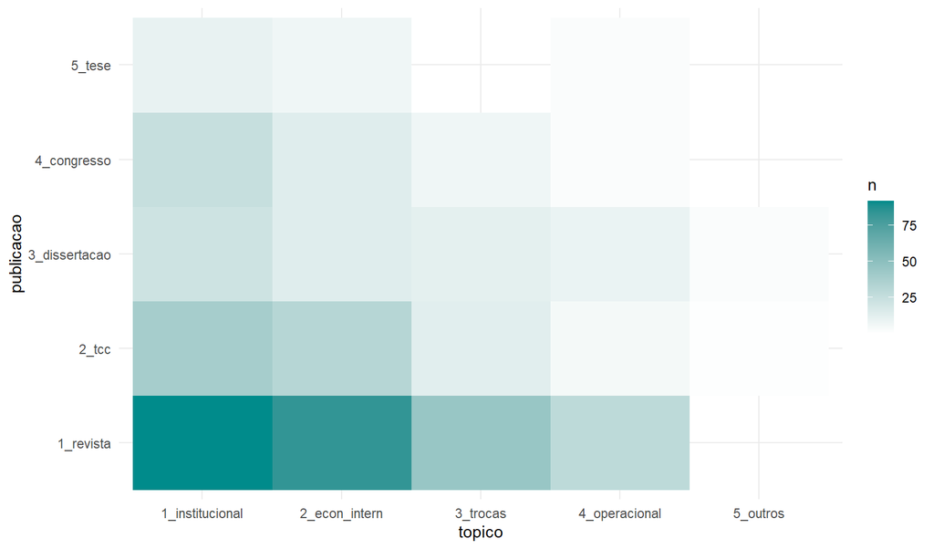

É esperado que, em termos absolutos, os tipos de publicação com maior frequencia estejam relacionados com os tópicos de maior frequencia. No entanto, é interessante relacionar as frequencias relativas, ponderadas pelas frequancias de cada classificação. Assim, divido a frequencia de cada par pelas frequencias de cada classificação do par:
$$f_{p,t}^{rel} = \dfrac{f_{p,t}}{f_{p}\cdot f_{t}}$$

…onde $f_{t}$ é a frequencia do tópico $t$, $f_{p}$ é a frequencia da publicação $p$, $f_{p,t}$ é a frequencia (absoluta) dos trabalhos com o tópico $t$ e a publicação $p$ e $f_{p,t}^{rel}$ é a frequencia relativa dos trabalhos com o tópico $t$ e a publicação $p$, ponderada pelas frequencias marginais.

| publicacao | topico | f_pt | f_t | f_p | f_rel |
| --- | --- | --- | --- | --- | --- |
| 1_revista | 1_institucional | 92 | 188 | 250 | 0.0019574468 |
| 1_revista | 2_econ_intern | 84 | 151 | 250 | 0.0022251656 |
| 1_revista | 3_trocas | 45 | 77 | 250 | 0.0023376623 |
| 1_revista | 4_operacional | 29 | 47 | 250 | 0.0024680851 |
| 2_tcc | 1_institucional | 39 | 188 | 90 | 0.0023049645 |
| 2_tcc | 2_econ_intern | 32 | 151 | 90 | 0.0023546726 |
| 2_tcc | 3_trocas | 13 | 77 | 90 | 0.0018759019 |
| 2_tcc | 4_operacional | 5 | 47 | 90 | 0.0011820331 |
| 2_tcc | 5_outros | 1 | 3 | 90 | 0.0037037037 |
| 3_dissertacao | 1_institucional | 22 | 188 | 59 | 0.0019834115 |

[output cut: 11 more lines]

*Gráfico da rede de conexões, com frequencias relativas, entre tópicos (exceto “outros”) e tipos de publicação:*

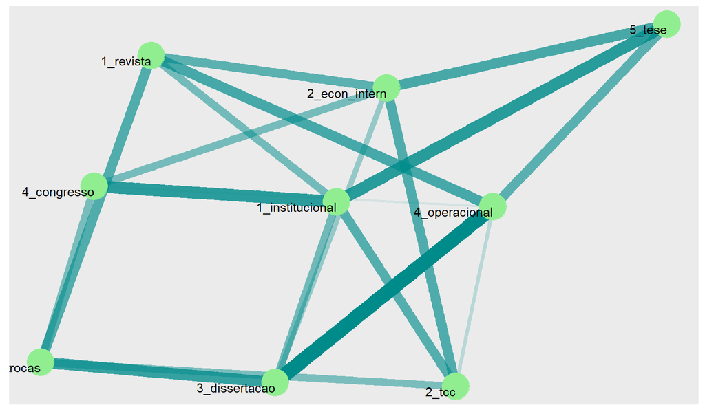

*Gráfico matricial das frequencias relativas entre os tópicos (exceto “outros”) e os tipos de publicação:*

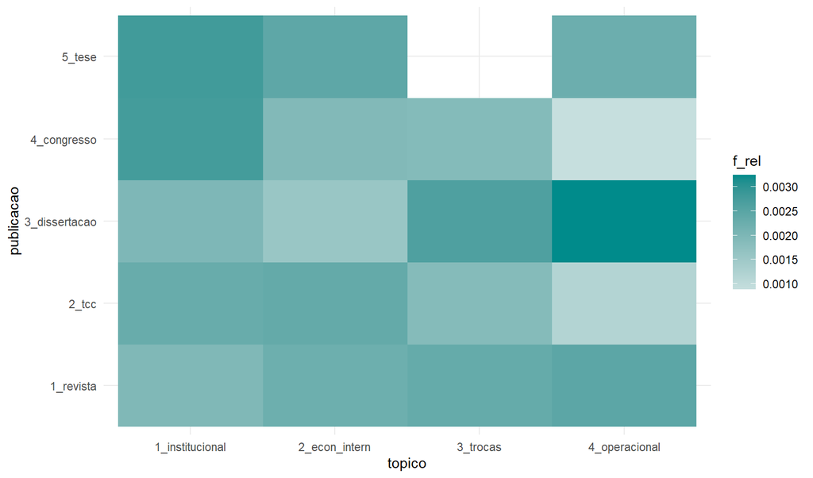

## 1.8 Palavras-chave stemized mais frequentes nos documentos, por tópicos

*Lista das top 50 stemized mais frequentes por tópico:*

| word | topico | n |
| --- | --- | --- |
| comerci | institucional | 138 |
| comerci | econ_intern | 115 |
| internacional | institucional | 104 |
| internacional | econ_intern | 80 |
| comerci | trocas | 55 |
| comerci | operacional | 41 |
| export | institucional | 40 |
| econom | econ_intern | 34 |
| export | econ_intern | 32 |
| internacional | operacional | 29 |

[output cut: 40 more lines]

*Gráfico das top 10 stemized por publicação (exceto “outros”):*

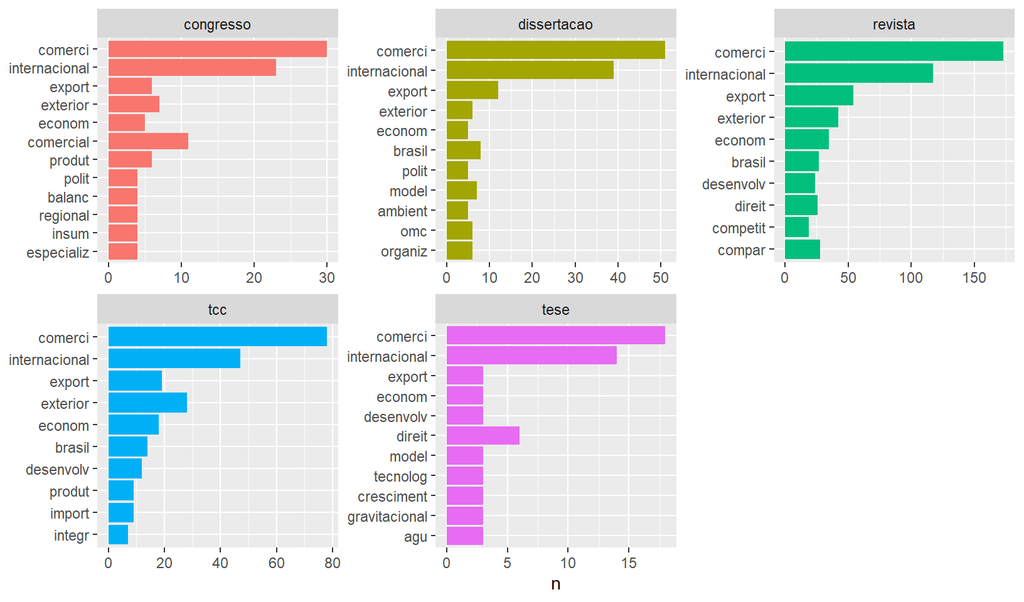

*Gráfico das top 10 stemized por tópico (exceto “outros”):*

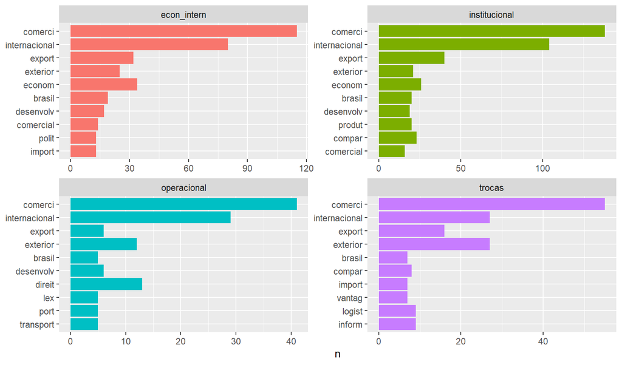

## 1.9 Palavras-chave de maiores tf-idf por tópicos

*Frequência do termo - tf -* é a frequencia relativa de uma palavra (token) no topico:
$$tf(\mathrm{token, topico}) = \dfrac{freq \ do \ token \ no \ topico}{qtd \ tokens \ no \ topico}$$

O idf diminui o peso de palavras usadas comumente e aumenta o peso para as palavras que não são muito usadas em uma coleção de documentos (aqui, tópicos). Dessa forma, com o método tf-idf em geral não é necessário retirar previamente as stopwords e termos com números, mas como aqui são poucas quantidades de palavras (apenas das palavras-chave dos documentos), vamos manter a exclusão das stopwords e as numéricas.

Veja sobre a “Lei de Zipf” aqui: https://pt.wikipedia.org/wiki/Lei_de_Zipf.

Como as frequencias são relativas por tópicos e o tópico “outros” tem baixíssima frequencia, este iria distorcer os resultados caso fosse mantido na ponderação, por isso o retirei dessa análise

*Lista das top 50 tf-idf (exceto tópico “outros”):*

| word | topico | n | tf | idf | tf_idf |
| --- | --- | --- | --- | --- | --- |
| marítimo | operacional | 3 | 0.007575758 | 1.3862944 | 0.010502230 |
| informação | trocas | 8 | 0.014440433 | 0.6931472 | 0.010009346 |
| competências | trocas | 4 | 0.007220217 | 1.3862944 | 0.010009346 |
| lex | operacional | 5 | 0.012626263 | 0.6931472 | 0.008751858 |
| business | trocas | 3 | 0.005415162 | 1.3862944 | 0.007507009 |
| cultural | trocas | 3 | 0.005415162 | 1.3862944 | 0.007507009 |
| empreendedorismo | trocas | 3 | 0.005415162 | 1.3862944 | 0.007507009 |
| habilidades | trocas | 3 | 0.005415162 | 1.3862944 | 0.007507009 |
| infraestrutura | trocas | 3 | 0.005415162 | 1.3862944 | 0.007507009 |
| inglês | trocas | 3 | 0.005415162 | 1.3862944 | 0.007507009 |

[output cut: 40 more lines]

*Gráfico das top 10 tf-idf por tópico (exceto “outros”):*

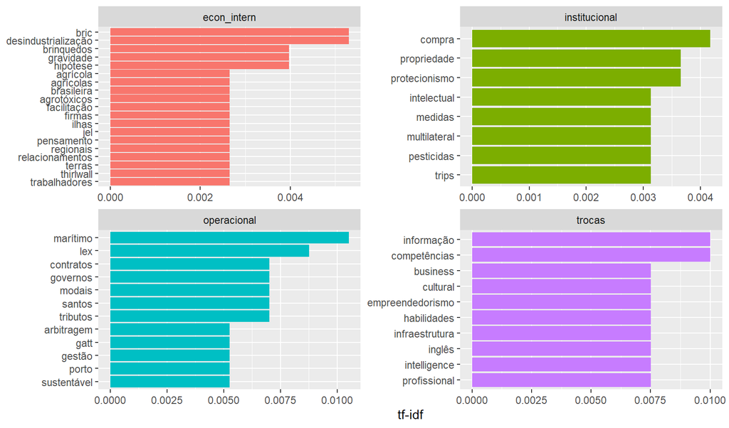

## 1.10 Palavras-chave stemized de maiores tf-idf por tópicos

*Lista das top 50 tf-idf (exceto tópico “outros”):*

| word | topico | n | tf | idf | tf_idf |
| --- | --- | --- | --- | --- | --- |
| competent | trocas | 5 | 0.009025271 | 1.3862944 | 0.012511682 |
| inform | trocas | 9 | 0.016245487 | 0.6931472 | 0.011260514 |
| govern | operacional | 3 | 0.007575758 | 1.3862944 | 0.010502230 |
| lex | operacional | 5 | 0.012626263 | 0.6931472 | 0.008751858 |
| port | operacional | 5 | 0.012626263 | 0.6931472 | 0.008751858 |
| business | trocas | 3 | 0.005415162 | 1.3862944 | 0.007507009 |
| cultural | trocas | 3 | 0.005415162 | 1.3862944 | 0.007507009 |
| empreendedor | trocas | 3 | 0.005415162 | 1.3862944 | 0.007507009 |
| infraestrutur | trocas | 3 | 0.005415162 | 1.3862944 | 0.007507009 |
| intelligenc | trocas | 3 | 0.005415162 | 1.3862944 | 0.007507009 |

[output cut: 40 more lines]

*Gráfico das top 10 tf-idf por tópico (exceto “outros”):*

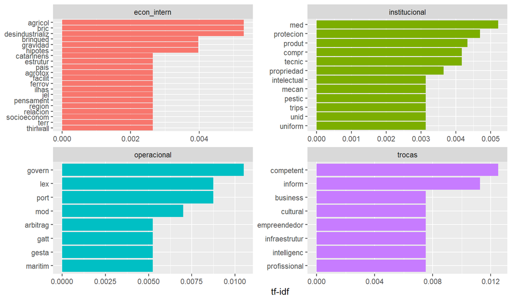